# Homework 03

2022-10-15

## Problem 0

Created a R project to organize my work, a R Markdown to write reproducible reports, relative paths to load data from local files, and reasonable naming structures to my files. Successfully established a git repository to upload commit history.

##Problem 1

```r
# install.packages("devtools")
devtools::install_github("p8105/p8105.datasets")
```

Had to download Rtools42 for windows to access the p8105 datasets (https://cran.r-project.org/bin/windows/Rtools/rtools42/rtools.html). Hopefully this is legit and I did not download a virus. Since that is completed I can move on to problem 1.

```r
library(p8105.datasets)
data("instacart")
View(instacart)
```

#### Read in the data

```r
data("instacart")

instacart =
  instacart %>%
  as_tibble(instacart)
```

This dataset contains 1384617 rows and 15 columns, with each row resprenting a single product from an instacart order. Variables include identifiers for user, order, and product; the order in which each product was added to the cart. There are several order-level variables, describing the day and time of the order, and number of days since prior order. Then there are several item-specific variables, describing the product name (e.g. Yogurt, Avocado), department (e.g. dairy and eggs, produce), and aisle (e.g. yogurt, fresh fruits), and whether the item has been ordered by this user in the past. In total, there are 39123 products found in 131209 orders from 131209 distinct users.

Below is a table summarizing the number of items ordered from aisle. In total, there are 134 aisles, with fresh vegetables and fresh fruits holding the most items ordered by far.

```r
instacart %>%
  count(aisle) %>%
  arrange(desc(n))
```

```
## # A tibble: 134 × 2
##    aisle                              n
##    <chr>                          <int>
##  1 fresh vegetables              150609
##  2 fresh fruits                  150473
##  3 packaged vegetables fruits     78493
##  4 yogurt                         55240
##  5 packaged cheese                41699
##  6 water seltzer sparkling water  36617
##  7 milk                           32644
##  8 chips pretzels                 31269
##  9 soy lactosefree                26240
## 10 bread                          23635
## # … with 124 more rows
```

Next is a plot that shows the number of items ordered in each aisle. Here, aisles are ordered by ascending number of items.

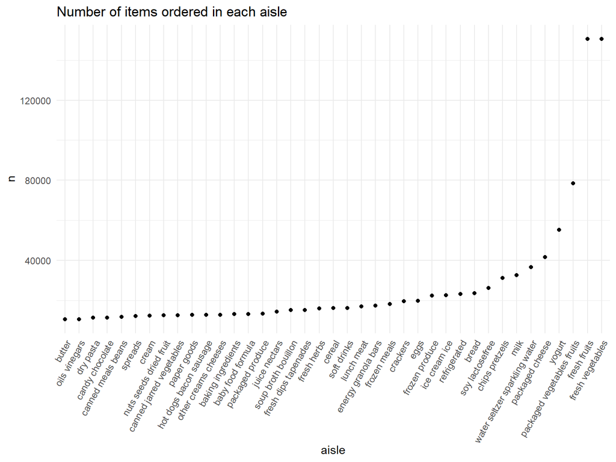

```r
instacart %>%
  count(aisle) %>%
  filter(n > 10000) %>%
  mutate(aisle = fct_reorder(aisle, n)) %>%
  ggplot(aes(x = aisle, y = n)) +
  geom_point() +
  labs(title = "Number of items ordered in each aisle") +
  theme(axis.text.x = element_text(angle = 60, hjust = 1))
```

Our next table shows the three most popular items in aisles `baking ingredients`, `dog food care`, and `packaged vegetables fruits`, and includes the number of times each item is ordered in your table.

```r
instacart %>%
  filter(aisle %in% c("baking ingredients", "dog food care", "packaged vegetables fruits")) %>%
  group_by(aisle) %>%
  count(product_name) %>%
  mutate(rank = min_rank(desc(n))) %>%
  filter(rank < 4) %>%
  arrange(desc(n)) %>%
  knitr::kable()
```

| aisle | product_name | n | rank |
| --- | --- | --- | --- |
| packaged vegetables fruits | Organic Baby Spinach | 9784 | 1 |
| packaged vegetables fruits | Organic Raspberries | 5546 | 2 |
| packaged vegetables fruits | Organic Blueberries | 4966 | 3 |
| baking ingredients | Light Brown Sugar | 499 | 1 |
| baking ingredients | Pure Baking Soda | 387 | 2 |
| baking ingredients | Cane Sugar | 336 | 3 |
| dog food care | Snack Sticks Chicken & Rice Recipe Dog Treats | 30 | 1 |
| dog food care | Organix Chicken & Brown Rice Recipe | 28 | 2 |
| dog food care | Small Dog Biscuits | 26 | 3 |

Finally is a table showing the mean hour of the day at which Pink Lady Apples and Coffee Ice Cream are ordered on each day of the week. This table has been formatted in an untidy manner for human readers. Pink Lady Apples are generally purchased slightly earlier in the day than Coffee Ice Cream, with the exception of day 5.

```r
instacart %>%
  filter(product_name %in% c("Pink Lady Apples", "Coffee Ice Cream")) %>%
  group_by(product_name, order_dow) %>%
  summarize(mean_hour = mean(order_hour_of_day)) %>%
  spread(key = order_dow, value = mean_hour) %>%
  knitr::kable(digits = 2)
```

| product_name | 0 | 1 | 2 | 3 | 4 | 5 | 6 |
| --- | --- | --- | --- | --- | --- | --- | --- |
| Coffee Ice Cream | 13.77 | 14.32 | 15.38 | 15.32 | 15.22 | 12.26 | 13.83 |
| Pink Lady Apples | 13.44 | 11.36 | 11.70 | 14.25 | 11.55 | 12.78 | 11.94 |

##Problem 2 Load, tidy, and otherwise wrangle the data. Your final dataset should include all originally observed variables and values; have useful variable names; include a weekday vs weekend variable; and encode data with reasonable variable classes. Describe the resulting dataset (e.g. what variables exist, how many observations, etc).

–>In this data set we have maintained the variable week, day_id, and day. There is a new variable named activity_num so that we can clearly see the different activities done on a given day. Next to activity_num is activity minutes so we can clearly see how long the patient spent doing various activities clearly. As TA Jimmy Kelliher pointed out on the discussion board all other variables besides activity_* should be retained. In this level of tidying the variables are retained.

```r
accel_1=
  read.csv("accel_data.csv") %>%
  janitor::clean_names() %>%
  pivot_longer(
    activity_1:activity_1440,
    names_to = "activity_num",
    values_to = "activity_minutes") %>%
  janitor::clean_names()
accel_1
```

```
## # A tibble: 50,400 × 5
##     week day_id day    activity_num activity_minutes
##    <int>  <int> <chr>  <chr>                   <dbl>
##  1     1      1 Friday activity_1               88.4
##  2     1      1 Friday activity_2               82.2
##  3     1      1 Friday activity_3               64.4
##  4     1      1 Friday activity_4               70.0
##  5     1      1 Friday activity_5               75.0
##  6     1      1 Friday activity_6               66.3
##  7     1      1 Friday activity_7               53.8
##  8     1      1 Friday activity_8               47.8
##  9     1      1 Friday activity_9               55.5
## 10     1      1 Friday activity_10              43.0
## # … with 50,390 more rows
```

Traditional analyses of accelerometer data focus on the total activity over the day. Using your tidied dataset, aggregate across minutes to create a total activity variable for each day, and create a table showing these totals. Are any trends apparent?

```r
accel_2=
  read.csv("accel_data.csv") %>%
  janitor::clean_names() %>%
  pivot_longer(
    activity_1:activity_1440,
    names_to = "activity_num",
    values_to = "activity_minutes") %>%
  mutate(
    day = factor(day, levels = c("Monday", "Tuesday", "Wednesday", "Thursday", "Friday", "Saturday", "Sunday")),
    weekday_vs_weekend =
      if_else(day %in% c("Saturday", "Sunday"), "Weekend", "Weekday")) %>%
   mutate(
    activity_minutes = as.numeric(activity_minutes)) %>%
  group_by(week, day) %>%
  summarise(total_activity = sum(activity_minutes)) %>%
  pivot_wider(
    names_from = "day",
    values_from = "total_activity"
  ) %>%
  janitor::clean_names()
accel_2
```

```
## # A tibble: 5 × 8
## # Groups:   week [5]
##    week  monday tuesday wednesday thursday  friday saturday sunday
##   <int>   <dbl>   <dbl>     <dbl>    <dbl>   <dbl>    <dbl>  <dbl>
## 1     1  78828. 307094.   340115.  355924. 480543.   376254 631105
## 2     2 295431  423245    440962   474048  568839    607175 422018
## 3     3 685910  381507    468869   371230  467420    382928 467052
## 4     4 409450  319568    434460   340291  154049      1440 260617
## 5     5 389080  367824    445366   549658  620860      1440 138421
```

Accelerometer data allows the inspection activity over the course of the day. Make a single-panel plot that shows the 24-hour activity time courses for each day and use color to indicate day of the week. Describe in words any patterns or conclusions you can make based on this graph.

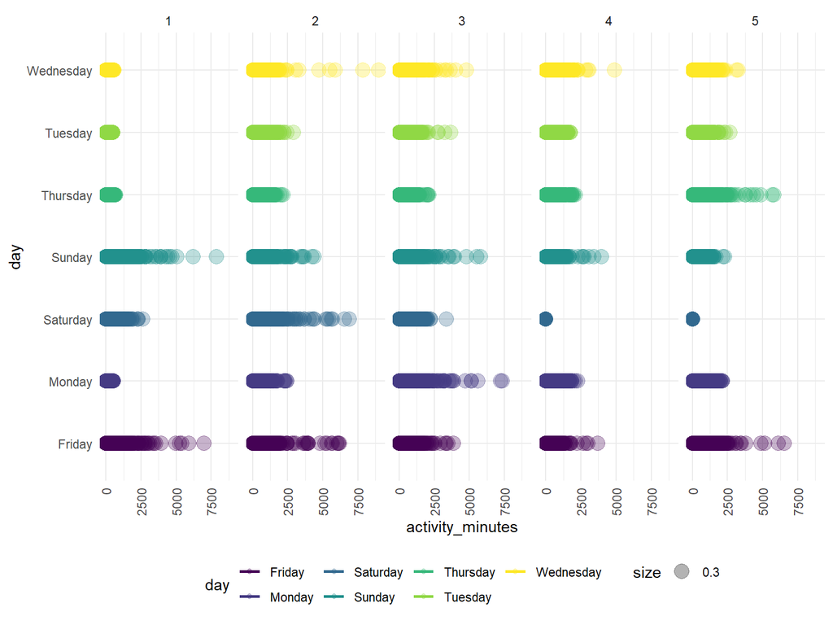

```r
accel_1 %>%
  ggplot(aes(x = activity_minutes, y = day, color = day)) +
  geom_point(aes(size = .3), alpha =.3)  +
  geom_smooth(se = FALSE) +
  facet_grid(. ~ week)+
  theme(axis.text.x = element_text(angle =90, vjust = 0.5, hjust=1))
```

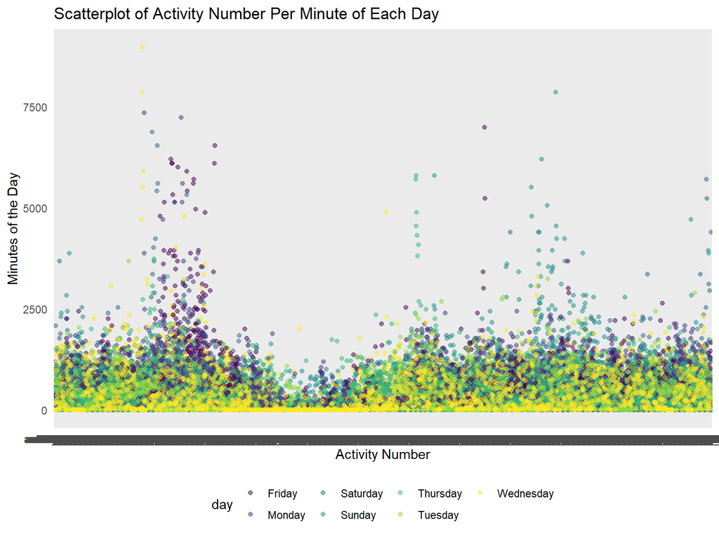

```r
ggplot(accel_1, aes(x = activity_num, y=activity_minutes, color = day )) +
  geom_point(alpha = 0.5) +
  labs(
    x = "Activity Number",
    y = "Minutes of the Day",
    title= "Scatterplot of Activity Number Per Minute of Each Day"
  )
```

##Problem 3

```r
library(p8105.datasets)
data("ny_noaa")
View(ny_noaa)
```

```r
data("ny_noaa")

ny_noaa =
  ny_noaa %>%
  as_tibble(ny_noaa)
```

Below is a table summarizing the number of different weather stations that have collected data. In total, there are 747 weather stations represented, with US1NYCN0011, US1NYCES0005, and USNYSF0030 with the least amount of data entries (days of weather information) all three having 30 days of entries.

```r
ny_noaa %>%
  count(id) %>%
  arrange(desc(n))
```

```
## # A tibble: 747 × 2
##    id              n
##    <chr>       <int>
##  1 USC00300055 10957
##  2 USC00300343 10957
##  3 USC00300889 10957
##  4 USC00304772 10957
##  5 USC00304836 10957
##  6 USC00304912 10957
##  7 USC00305426 10957
##  8 USC00305714 10957
##  9 USC00306196 10957
## 10 USC00309425 10957
## # … with 737 more rows
```

Do some data cleaning. Create separate variables for year, month, and day.

```r
 ny_noaa_tidy1=
  ny_noaa %>%
  janitor::clean_names() %>%
   separate(date, into = c("year", "month", "day")) %>%
  mutate(year = as.integer(year), month = as.integer(month), day = as.integer(day)) %>%
  mutate(month = month.name[as.integer(month)])
ny_noaa_tidy1
```

```
## # A tibble: 2,595,176 × 9
##    id           year month      day  prcp  snow  snwd tmax  tmin
##    <chr>       <int> <chr>    <int> <int> <int> <int> <chr> <chr>
##  1 US1NYAB0001  2007 November     1    NA    NA    NA <NA>  <NA>
##  2 US1NYAB0001  2007 November     2    NA    NA    NA <NA>  <NA>
##  3 US1NYAB0001  2007 November     3    NA    NA    NA <NA>  <NA>
##  4 US1NYAB0001  2007 November     4    NA    NA    NA <NA>  <NA>
##  5 US1NYAB0001  2007 November     5    NA    NA    NA <NA>  <NA>
##  6 US1NYAB0001  2007 November     6    NA    NA    NA <NA>  <NA>
##  7 US1NYAB0001  2007 November     7    NA    NA    NA <NA>  <NA>
##  8 US1NYAB0001  2007 November     8    NA    NA    NA <NA>  <NA>
##  9 US1NYAB0001  2007 November     9    NA    NA    NA <NA>  <NA>
## 10 US1NYAB0001  2007 November    10    NA    NA    NA <NA>  <NA>
## # … with 2,595,166 more rows
```

Ensure observations for temperature are in degrees Celsuis not “tenths of degrees C”. Ensure precipitation and snowfall are given in reasonable units. Since snowfall is already in mm it does not need to be changed but precipitation is in tenths of a mm so that needs to be correct in a similar fashion to the minimum and maximum temperature.

```r
ny_noaa_tidy2 =
  ny_noaa %>%
  sample_n(2000) %>%
  janitor::clean_names() %>%
   separate(date, into = c("year", "month", "day")) %>%
  mutate(year = as.integer(year), month = as.integer(month), day = as.integer(day)) %>%
  mutate(month = month.name[as.integer(month)]) %>%
  mutate(tmin= as.numeric(tmin)) %>%
  mutate(tmin = as.numeric(tmin / 10)) %>%
  mutate(tmax= as.numeric(tmax)) %>%
  mutate(tmax = as.numeric(tmax / 10)) %>%
  mutate(prcp= as.numeric(prcp)) %>%
  mutate(prcp = as.numeric(prcp / 10)) %>%
 select(id, year, month, day, prcp, snow, snwd, tmax, tmin)
ny_noaa_tidy2
```

```
## # A tibble: 2,000 × 9
##    id           year month      day  prcp  snow  snwd  tmax  tmin
##    <chr>       <int> <chr>    <int> <dbl> <int> <int> <dbl> <dbl>
##  1 USC00303365  1990 April        1   0       0     0  NA    NA
##  2 USC00306196  2010 January      1   2.3    25    76  NA    NA
##  3 USW00094725  1997 January     25  11.4    20    76   5   -10
##  4 USC00307721  1995 November    18   3.8     0     0  NA    NA
##  5 US1NYSC0001  2008 December    30   0       0   140  NA    NA
##  6 USC00303033  1993 July        18   0       0     0  26.7  11.7
##  7 USC00305512  2007 May         26   0       0     0  28.3  12.8
##  8 USC00302137  1986 October     16   0.3     0     0  NA    NA
##  9 USC00309495  2000 January     23   0       0     0 -13.3 -23.9
## 10 USC00303050  1987 January      5   0       0   279  NA    NA
## # … with 1,990 more rows
```

```r
ny_noaa_tidy2 %>%
  count(snow) %>%
arrange(desc(n))
```

```
## # A tibble: 47 × 2
##     snow     n
##    <int> <int>
##  1     0  1583
##  2    NA   255
##  3    25    32
##  4    13    17
##  5    51    17
##  6    76    11
##  7     8    10
##  8     5     6
##  9   102     6
## 10    20     5
## # … with 37 more rows
```

Trying to get the tmax mean to work. After multiple attempts I am successful.

```r
mean(pull(ny_noaa_tidy2, tmax), na.rm = TRUE)
```

```
## [1] 13.64405
```

```r
pull(ny_noaa_tidy2, tmax) %>%
  mean(na.rm = TRUE)
```

```
## [1] 13.64405
```

Make a two-panel plot showing the average max temperature in January and in July in each station across years. Is there any observable / interpretable structure? Any outliers?

```r
avg_max_temp_JanJuly = ny_noaa_tidy2 %>%
  group_by(month, year, id) %>%
  filter(month == "January" | month== "July") %>%
  summarize(tmax_mean = mean(tmax, na.rm = TRUE))
```

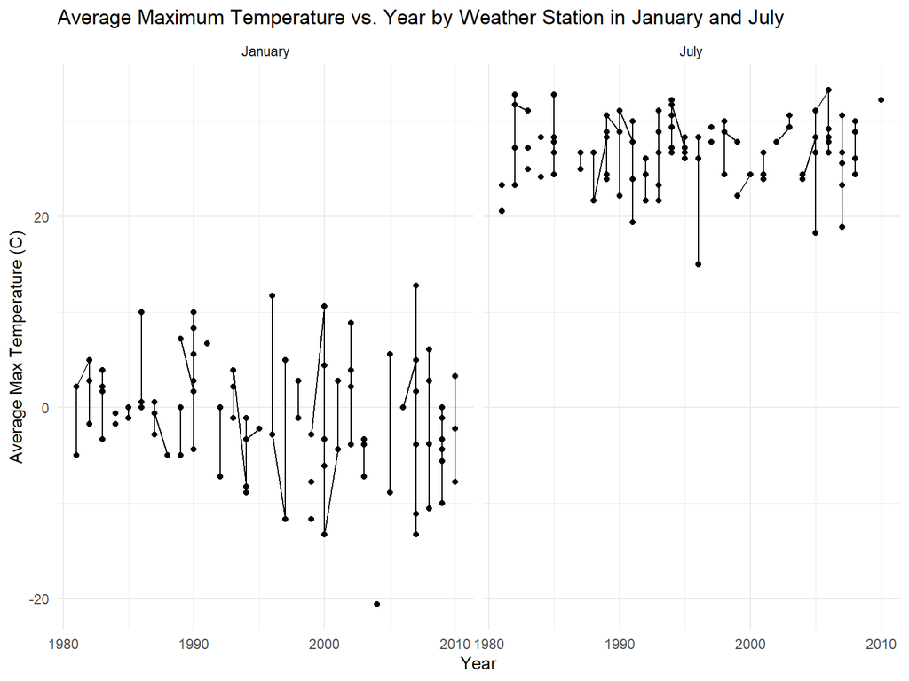

```r
  ggplot(avg_max_temp_JanJuly, aes(x = year, y = tmax_mean)) +
  geom_point()+
    geom_path()+
    facet_grid(.~month)+
  labs(
    title = "Average Maximum Temperature vs. Year by Weather Station in January and July",
    x = "Year",
    y = "Average Max Temperature (C)")
```

Make a two-panel plot showing (i) tmax vs tmin for the full dataset (note that a scatterplot may not be the best option); and (ii) make a plot showing the distribution of snowfall values greater than 0 and less than 100 separately by year.

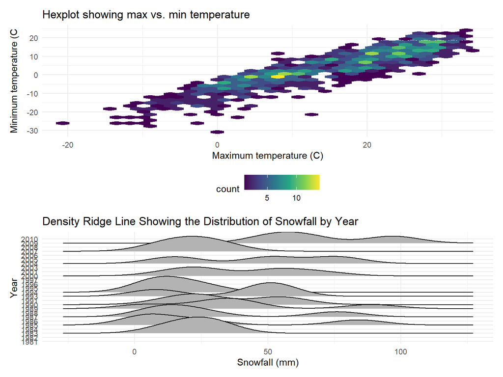

```r
tmax_tmin = ny_noaa_tidy2 %>%
drop_na() %>%
  ggplot(aes(x = tmax, y=tmin)) + geom_hex() +
  labs(title = "Hexplot showing max vs. min temperature",
       x= "Maximum temperature (C)",
       y= "Minimum temperature (C")

snowfall = ny_noaa_tidy2 %>%
  drop_na() %>%
  filter(snow > 0 & snow < 100) %>%
  ggplot(aes(x =snow, y = factor(year))) + geom_density_ridges() +
  labs(title = "Density Ridge Line Showing the Distribution of Snowfall by Year",
       x= "Snowfall (mm)",
       y= "Year")

tmax_tmin/snowfall
```